# Network Analysis - CEI II

Diego Diaz-Milanes

22/03/2025

# 0. STUDY CONTEXT AND OBJECTIVES

**Tile:** Revalidation of the Curiosity and Exploration Inventory-II (CEI-II) Using Network Analysis

**Authors:**  
Sergio Navas-León<sup>1</sup>,  
Pedro Juan Pérez-Moreno<sup>2</sup>,  
Carmen Santin Vilarino<sup>2,*</sup>,  
Diego Diaz-Milanes<sup>3,4,*</sup>

**Affiliation:**

<sup>1</sup> Centro de Investigación Nebrija en Cognición (CINC), Universidad Nebrija, Madrid, Spain

<sup>2</sup> Department of Clinical and Experimental Psychology, University of Huelva, Huelva, Spain

<sup>3</sup> Department of Quantitative Methods, Universidad Loyola Andalucía, Sevilla, Spain

<sup>4</sup> Health Research Institute, University of Canberra, Canberra, ACT, Australia

**Corresponding Authors:**

santin@dpsi.uhu.es

ddiaz@uloyola.es

This R Markdown document includes the data and R code associated with the present study, with the aim of ensuring full transparency and replicability of the data analysis.

The analysis is structured into six main steps. First, the dataset was loaded and preprocessed. Second, descriptive analyses were performed to examine the sociodemographic characteristics of the participants, the distribution of the CEI-II items, and potential gender differences.

Third, network analysis was conducted on the CEI-II items. Fourth, tests of network invariance were applied to compare structural differences across gender groups. Fifth, a Bayesian network model was estimated. Finally, the predictive capacity of the different models was evaluated.

# 1. DATA LOADING & PROCESSING

In this section, the packages, function design, and data used are listed. Then, data processing—including variable selection and filtering by units of analysis—was performed.

## 1.1. Import Packages

A total of 17 packages were loaded:

```r
library(readxl)
library(tidyr)
library(dplyr)
library(psych)
library(ggplot2)
library(semTools)
library(effectsize)
library(EGAnet)
library(qgraph)
library(NetworkComparisonTest)
library(bootnet)
library(mgm)
library(bnlearn)
library(caret)
library(forcats)
library(knitr)
library(kableExtra)

x <- htmltools::HTML("%<%")

# Define the packages and functions (with inline code formatting)
packages_info <- data.frame(
  Package = c(
    "readxl", "tidyr", "dplyr", "psych", "semTools", "ggplot2", "effectsize",
    "EGAnet", "qgraph", "NetworkComparisonTest", "bootnet", "mgm", "bnlearn",
    "caret", "forcats", "knitr", "kableExtra"
  ),
  Functions = c(
    "`read_excel`",
    paste0(x,", reshaping support"),
    paste0("`select`, `mutate`, `filter`, `group_by`, `summarise`, `bind_rows`, ",x),
    "`describe`, `polychoric`",
    "`mardiaSkew`, `mardiaKurtosis`",
    "`ggplot`, `aes`, `geom_line`, `labs`, `theme_bw`, etc.",
    "`cohens_d`",
    "`bootEGA`, `dimensionStability`",
    "`qgraph`",
    "`NCT`, `plot`",
    "`estimateNetwork`, `bootnet`, `corStability`",
    "`mgm`, `predict`",
    "`boot.strength`, `averaged.network`, `bn.fit`, `predict`",
    "`confusionMatrix`",
    "`fct_reorder`",
    "`kable`",
    "`kable_styling`, `add_header_above`"
  ),
  stringsAsFactors = FALSE
)

# Get package versions
packages_info$Version <- sapply(packages_info$Package, function(pkg) {
  as.character(packageVersion(pkg))
})

# Reorder columns
packages_info <- packages_info[, c("Package", "Version", "Functions")]

# Display as a nicely styled table
knitr::kable(packages_info, caption = "Table 1. Packages Used, Versions, and Functions") %>%
  kableExtra::kable_styling(full_width = FALSE, position = "center")
```

Table 1. Packages Used, Versions, and Functions

| Package | Version | Functions |
| --- | --- | --- |
| readxl | 1.4.3 | `read_excel` |
| tidyr | 1.3.1 | %<%, reshaping support |
| dplyr | 1.1.4 | `select`, `mutate`, `filter`, `group_by`, `summarise`, `bind_rows`, %<% |
| psych | 2.4.1 | `describe`, `polychoric` |
| semTools | 0.5.6 | `mardiaSkew`, `mardiaKurtosis` |
| ggplot2 | 3.5.1 | `ggplot`, `aes`, `geom_line`, `labs`, `theme_bw`, etc. |
| effectsize | 0.8.9 | `cohens_d` |
| EGAnet | 2.0.4 | `bootEGA`, `dimensionStability` |
| qgraph | 1.9.8 | `qgraph` |
| NetworkComparisonTest | 2.2.2 | `NCT`, `plot` |
| bootnet | 1.5.6 | `estimateNetwork`, `bootnet`, `corStability` |
| mgm | 1.2.14 | `mgm`, `predict` |
| bnlearn | 4.9 | `boot.strength`, `averaged.network`, `bn.fit`, `predict` |
| caret | 6.0.94 | `confusionMatrix` |
| forcats | 1.0.0 | `fct_reorder` |
| knitr | 1.45 | `kable` |
| kableExtra | 1.4.0 | `kable_styling`, `add_header_above` |

Design and generation of a formula for plotting centrality measures of two networks.

```r
compareCentrality <- function(net1, net2,
                              include = c("Strength",
                                          "Closeness",
                                          "Betweenness",
                                          "ExpectedInfluence",
                                          "all",
                                          "All"),
                              orderBy = c("Strength",
                                          "Closeness",
                                          "Betweenness",
                                          "ExpectedInfluence"),
                              decreasing = T,
                              legendName = '',
                              net1Name = 'Network 1',
                              net2Name = 'Network 2'){

  if(include == "All" | include == "all"){
    include = c("Strength",
                "Closeness",
                "Betweenness",
                "ExpectedInfluence")
  }

  df <- centralityTable(net1, net2) %>% filter(measure %in% include)

  df %>%
    mutate(graph = case_when(graph == 'graph 1' ~ net1Name,
                             graph == 'graph 2' ~ net2Name),
           graph = as.factor(graph),
           node = as.factor(node)) %>%

    mutate(node = fct_reorder(node, value)) %>%

    ggplot(aes(x = node, y = value, group = graph)) +

    geom_line(aes(linetype = graph), size = 1) +

    labs(x = '', y = '') +

    scale_linetype_discrete(name = legendName) +

    coord_flip() +

    facet_grid(~measure) +

    theme_bw()

}
```

## 1.2. Data Loading

The dataset from the **Health Behavior in University (HBU)** project (UHU-6272020) was loaded, including only the minimum set of variables required for the present study. The dataset can be found in the following link: https://github.com/diediamil/Network_Analysis_CEI-II/raw/refs/heads/main/HBU_DB.xlsx

```r
hbu <- read_excel("HBU_DB.xlsx")
hbu
```

| CI | gender | age | CEI1 | CEI2 | CEI3 | CEI4 | CEI5 | CEI6 | CEI7 | CEI8 | CEI9 | CEI10 | CEI_TOTAL |
| --- | --- | --- | --- | --- | --- | --- | --- | --- | --- | --- | --- | --- | --- |
| Invalid | NA | NA | NA | NA | NA | NA | NA | NA | NA | NA | NA | NA | NA |
| Invalid | NA | NA | NA | NA | NA | NA | NA | NA | NA | NA | NA | NA | NA |
| Invalid | NA | NA | NA | NA | NA | NA | NA | NA | NA | NA | NA | NA | NA |
| Invalid | NA | NA | NA | NA | NA | NA | NA | NA | NA | NA | NA | NA | NA |
| Invalid | NA | NA | NA | NA | NA | NA | NA | NA | NA | NA | NA | NA | NA |
| Invalid | NA | NA | NA | NA | NA | NA | NA | NA | NA | NA | NA | NA | NA |
| Invalid | NA | NA | NA | NA | NA | NA | NA | NA | NA | NA | NA | NA | NA |
| Invalid | NA | NA | NA | NA | NA | NA | NA | NA | NA | NA | NA | NA | NA |
| Invalid | NA | NA | NA | NA | NA | NA | NA | NA | NA | NA | NA | NA | NA |
| Invalid | NA | NA | NA | NA | NA | NA | NA | NA | NA | NA | NA | NA | NA |

[output cut: 960 more lines]

## 1.3. Filtering

Filters were applied to remove participants who did not complete the informed consent (**CI**), were minors or outside the typical age range for Spanish university students (from 18 to 26 years old), and to exclude cases with missing values:

```r
initial_rows <- nrow(hbu)
hbu <- hbu[hbu$CI == "Valid",]
hbu <- hbu[!is.na(hbu$gender),]
hbu <- hbu[!is.na(hbu$age),]
hbu <- hbu[hbu$age >= 18 & hbu$age <= 26,]
hbu <- hbu[!is.na(hbu$CEI_TOTAL),]

print(paste("Initial number of rows:", initial_rows, "| Final number of rows:", nrow(hbu)))
```

```
## [1] "Initial number of rows: 970 | Final number of rows: 849"
```

```r
hbu
```

| CI | gender | age | CEI1 | CEI2 | CEI3 | CEI4 | CEI5 | CEI6 | CEI7 | CEI8 | CEI9 | CEI10 | CEI_TOTAL |
| --- | --- | --- | --- | --- | --- | --- | --- | --- | --- | --- | --- | --- | --- |
| Valid | Female | 23 | 4 | 3 | 5 | 5 | 5 | 4 | 4 | 4 | 5 | 3 | 42 |
| Valid | Female | 20 | 5 | 3 | 3 | 4 | 5 | 5 | 4 | 2 | 2 | 5 | 38 |
| Valid | Female | 21 | 3 | 2 | 3 | 3 | 4 | 2 | 1 | 1 | 1 | 1 | 21 |
| Valid | Female | 19 | 4 | 3 | 4 | 4 | 4 | 3 | 4 | 3 | 4 | 3 | 36 |
| Valid | Male | 22 | 2 | 3 | 2 | 3 | 2 | 3 | 2 | 2 | 3 | 2 | 24 |
| Valid | Female | 23 | 3 | 3 | 2 | 2 | 2 | 1 | 2 | 2 | 3 | 4 | 24 |
| Valid | Female | 22 | 2 | 3 | 3 | 4 | 3 | 4 | 4 | 2 | 2 | 2 | 29 |
| Valid | Female | 22 | 3 | 3 | 4 | 3 | 3 | 3 | 3 | 3 | 3 | 4 | 32 |
| Valid | Female | 20 | 5 | 5 | 4 | 4 | 5 | 4 | 4 | 4 | 5 | 5 | 45 |
| Valid | Female | 23 | 4 | 4 | 3 | 5 | 5 | 4 | 3 | 4 | 4 | 3 | 39 |

[output cut: 839 more lines]

## 1.4. Variable Selection

Creation of dataframes tailored to meet the requirements of the forthcoming data analyses.

**1. Dataframe for the analysis of individual items**

The following table displays the first five rows of the set of items from the CEI-II instrument, used in the present study.

```r
# Prepare the dataframe
hbu$gender <- as.factor(hbu$gender)
CEI_items <- dplyr::select(hbu, CEI1:CEI10)
pieColor <- rep("#EB9446", length(CEI_items))

# Display first 5 rows with a formatted table
head(CEI_items, 5) %>%
  kable(caption = "Table 2. Set of items from the CEI-II") %>%
  kable_styling(full_width = FALSE, position = "center")
```

Table 2. Set of items from the CEI-II

| CEI1 | CEI2 | CEI3 | CEI4 | CEI5 | CEI6 | CEI7 | CEI8 | CEI9 | CEI10 |
| --- | --- | --- | --- | --- | --- | --- | --- | --- | --- |
| 4 | 3 | 5 | 5 | 5 | 4 | 4 | 4 | 5 | 3 |
| 5 | 3 | 3 | 4 | 5 | 5 | 4 | 2 | 2 | 5 |
| 3 | 2 | 3 | 3 | 4 | 2 | 1 | 1 | 1 | 1 |
| 4 | 3 | 4 | 4 | 4 | 3 | 4 | 3 | 4 | 3 |
| 2 | 3 | 2 | 3 | 2 | 3 | 2 | 2 | 3 | 2 |

**2. Dataframe for exploring gender differences**

The following table shows the first five rows of the dataset including the CEI-II item responses, the total score, and participants’ gender.

```r
# Select CEI items, total score, and gender
CEI_gender <- dplyr::select(hbu, CEI1:CEI10, CEI_TOTAL, gender)

# Display first 5 rows with styling
head(CEI_gender, 5) %>%
  kable(caption = "Table 3. CEI-II items, total score, and gender variable") %>%
  kable_styling(full_width = FALSE, position = "center")
```

Table 3. CEI-II items, total score, and gender variable

| CEI1 | CEI2 | CEI3 | CEI4 | CEI5 | CEI6 | CEI7 | CEI8 | CEI9 | CEI10 | CEI_TOTAL | gender |
| --- | --- | --- | --- | --- | --- | --- | --- | --- | --- | --- | --- |
| 4 | 3 | 5 | 5 | 5 | 4 | 4 | 4 | 5 | 3 | 42 | Female |
| 5 | 3 | 3 | 4 | 5 | 5 | 4 | 2 | 2 | 5 | 38 | Female |
| 3 | 2 | 3 | 3 | 4 | 2 | 1 | 1 | 1 | 1 | 21 | Female |
| 4 | 3 | 4 | 4 | 4 | 3 | 4 | 3 | 4 | 3 | 36 | Female |
| 2 | 3 | 2 | 3 | 2 | 3 | 2 | 2 | 3 | 2 | 24 | Male |

**3. Dataframe for assessing model invariance across gender**

The following table displays the first five rows of the dataset used for testing network invariance by gender, including the CEI-II items and participants’ gender.

```r
# Select CEI-II items and gender for invariance analysis
CEI_invariance <- dplyr::select(hbu, CEI1:CEI10, gender)

# Display first 5 rows with a styled table
head(CEI_invariance, 5) %>%
  kable(caption = "Table 4. CEI-II items and gender variable for network invariance analysis") %>%
  kable_styling(full_width = FALSE, position = "center")
```

Table 4. CEI-II items and gender variable for network invariance analysis

| CEI1 | CEI2 | CEI3 | CEI4 | CEI5 | CEI6 | CEI7 | CEI8 | CEI9 | CEI10 | gender |
| --- | --- | --- | --- | --- | --- | --- | --- | --- | --- | --- |
| 4 | 3 | 5 | 5 | 5 | 4 | 4 | 4 | 5 | 3 | Female |
| 5 | 3 | 3 | 4 | 5 | 5 | 4 | 2 | 2 | 5 | Female |
| 3 | 2 | 3 | 3 | 4 | 2 | 1 | 1 | 1 | 1 | Female |
| 4 | 3 | 4 | 4 | 4 | 3 | 4 | 3 | 4 | 3 | Female |
| 2 | 3 | 2 | 3 | 2 | 3 | 2 | 2 | 3 | 2 | Male |

# 2. DESCRIPTIVE ANALYSIS

## 2.1. Sociodemographic

Participants distribution by gender and age:

```r
# Gender distribution
gender_table <- table(hbu$gender)
gender_percent <- round(prop.table(gender_table) * 100, 2)

gender_df <- data.frame(
  Gender = names(gender_table),
  Frequency = round(as.numeric(gender_table), 2),
  Percentage = paste0(gender_percent, "%")
)

# Age summary
age_summary <- summary(hbu$age)
age_sd <- round(sd(hbu$age), 2)

age_df <- data.frame(
  Statistic = names(age_summary),
  Value = round(as.numeric(age_summary), 2)
) %>%
  bind_rows(data.frame(Statistic = "Standard Deviation", Value = age_sd))

# Display tables
kable(gender_df, caption = "Table 5. Gender distribution (frequency and %)") %>%
  kable_styling(full_width = FALSE, position = "center")
```

Table 5. Gender distribution (frequency and %)

| Gender | Frequency | Percentage |
| --- | --- | --- |
| Female | 633 | 74.56% |
| Male | 216 | 25.44% |

```r
kable(age_df, caption = "Table 6. Age summary statistics") %>%
  kable_styling(full_width = FALSE, position = "center")
```

Table 6. Age summary statistics

| Statistic | Value |
| --- | --- |
| Min. | 18.00 |
| 1st Qu. | 19.00 |
| Median | 20.00 |
| Mean | 20.66 |
| 3rd Qu. | 22.00 |
| Max. | 26.00 |
| Standard Deviation | 2.15 |

## 2.2. Items

Univariate descriptive analysis of the items included in the CEI-II instrument:

```r
# Descriptive statistics
descrgen <- describe(CEI_items)

# Build dataframe with selected stats
lgen <- list(c(1:10), descrgen$mean, descrgen$sd, descrgen$min,
             descrgen$max, descrgen$skew, descrgen$kurtosis)
lgen <- as.data.frame(lgen)

# Round and rename columns
lgen <- lgen %>%
  mutate_if(is.numeric, round, digits = 3)

colnames(lgen) <- c("Item", "Mean", "SD", "Min", "Max", "Skew", "Kurtosis")

# Display table
kable(lgen, caption = "Table 7. Descriptive statistics for CEI-II items") %>%
  kable_styling(full_width = FALSE, position = "center")
```

Table 7. Descriptive statistics for CEI-II items

| Item | Mean | SD | Min | Max | Skew | Kurtosis |
| --- | --- | --- | --- | --- | --- | --- |
| 1 | 3.549 | 0.903 | 1 | 5 | -0.342 | -0.041 |
| 2 | 2.880 | 1.137 | 1 | 5 | -0.130 | -0.749 |
| 3 | 3.536 | 1.012 | 1 | 5 | -0.367 | -0.298 |
| 4 | 3.605 | 0.966 | 1 | 5 | -0.472 | -0.088 |
| 5 | 3.828 | 0.895 | 1 | 5 | -0.486 | -0.141 |
| 6 | 3.190 | 1.129 | 1 | 5 | -0.253 | -0.705 |
| 7 | 3.325 | 1.083 | 1 | 5 | -0.348 | -0.475 |
| 8 | 3.052 | 1.075 | 1 | 5 | -0.171 | -0.568 |
| 9 | 3.565 | 1.013 | 1 | 5 | -0.446 | -0.250 |
| 10 | 3.038 | 1.245 | 1 | 5 | -0.046 | -0.973 |

Assessment of multivariate normality assumptions based on Mardia’s tests for skewness and kurtosis, applied to the set of items included in the CEI-II instrument:

```r
# Run Mardia's tests
skew_result <- mardiaSkew(CEI_items)
kurt_result <- mardiaKurtosis(CEI_items)

# Round and extract values
mardia_df <- data.frame(
  Test = c("Mardia Skewness", "Mardia Kurtosis"),
  Statistic = round(c(skew_result[2], kurt_result[2]), 3),
  p_value = round(c(skew_result[4], kurt_result[3]), 3)
)
row.names(mardia_df) <- 1:2
# Show table
kable(mardia_df, caption = "Table 8: Mardia's Tests for Multivariate Normality")
```

Table 8: Mardia’s Tests for Multivariate Normality

| Test | Statistic | p_value |
| --- | --- | --- |
| Mardia Skewness | 687.001 | 0 |
| Mardia Kurtosis | 22.018 | 0 |

## 2.3. Items by Gender

```r
# Lista de ítems y etiquetas
items <- c("CEI1", "CEI2", "CEI3", "CEI4", "CEI5",
           "CEI6", "CEI7", "CEI8", "CEI9", "CEI10", "CEI_TOTAL")

item_labels <- c(
  "1. I actively seek as much information as I can in new situations.",
  "2. I am the type of person who really enjoys the uncertainty of everyday life.",
  "3. I am at my best when doing something that is complex or challenging.",
  "4. Everywhere I go, I am out looking for new things or experiences.",
  "5. I view challenging situations as an opportunity to grow and learn.",
  "6. I like to do things that are a little frightening.",
  "7. I am always looking for experiences that challenge how I think about myself and the world.",
  "8. I prefer jobs that are excitingly unpredictable.",
  "9. I frequently seek out opportunities to challenge myself and grow as a person.",
  "10. I am the kind of person who embraces unfamiliar people, events, and places.",
  "Total score"
)

# Crear tabla de resultados
results <- lapply(seq_along(items), function(i) {
  item <- items[i]
  label <- item_labels[i]

  # Obtener estadísticas por grupo
  stats <- CEI_gender %>%
    group_by(gender) %>%
    summarise(
      mean = round(mean(.data[[item]], na.rm = TRUE), 3),
      sd = round(sd(.data[[item]], na.rm = TRUE), 3)
    )

  male_val <- paste0(stats$mean[stats$gender == "Male"], " (", stats$sd[stats$gender == "Male"], ")")
  female_val <- paste0(stats$mean[stats$gender == "Female"], " (", stats$sd[stats$gender == "Female"], ")")

  # t-test
  t_result <- t.test(as.formula(paste(item, "~ gender")), data = CEI_gender)
  t_stat <- round(t_result$statistic, 3)
  df <- round(t_result$parameter, 3)
  p_val <- round(t_result$p.value,3)

  # Efecto (Cohen's d)
  d_val <- cohens_d(as.formula(paste(item, "~ gender")), data = CEI_gender)$Cohens_d
  d_val <- round(d_val, 3)

  # Combinar resultados
  data.frame(
    Item = label,
    Male = male_val,
    Female = female_val,
    T_statistic = paste0(t_stat, " (", df, ")"),
    p_value = p_val,
    Effect_size = d_val
  )
})

# Unir todos los ítems
final_table <- bind_rows(results)

# Mostrar tabla
kable(final_table, caption = "Table 9. Mean (SD) by Gender, t-test Results, p-value and Effect Sizes for CEI Items")
```

Table 9. Mean (SD) by Gender, t-test Results, p-value and Effect Sizes for CEI Items

| Item | Male | Female | T_statistic | p_value | Effect_size |
| --- | --- | --- | --- | --- | --- |
| 1. I actively seek as much information as I can in new situations. | 3.639 (0.904) | 3.518 (0.902) | -1.695 (371.147) | 0.091 | -0.134 |
| 2. I am the type of person who really enjoys the uncertainty of everyday life. | 3.259 (1.086) | 2.75 (1.125) | -5.892 (383.989) | 0.000 | -0.456 |
| 3. I am at my best when doing something that is complex or challenging. | 3.806 (0.969) | 3.444 (1.011) | -4.684 (386.373) | 0.000 | -0.361 |
| 4. Everywhere I go, I am out looking for new things or experiences. | 3.736 (0.91) | 3.561 (0.981) | -2.396 (398.03) | 0.017 | -0.182 |
| 5. I view challenging situations as an opportunity to grow and learn. | 4.023 (0.849) | 3.761 (0.901) | -3.851 (392.373) | 0.000 | -0.295 |
| 6. I like to do things that are a little frightening. | 3.356 (1.124) | 3.133 (1.126) | -2.526 (372.556) | 0.012 | -0.199 |
| 7. I am always looking for experiences that challenge how I think about myself and the world. | 3.56 (0.991) | 3.245 (1.102) | -3.921 (409.711) | 0.000 | -0.293 |
| 8. I prefer jobs that are excitingly unpredictable. | 3.338 (1.044) | 2.954 (1.069) | -4.637 (379.698) | 0.000 | -0.361 |
| 9. I frequently seek out opportunities to challenge myself and grow as a person. | 3.773 (0.969) | 3.494 (1.019) | -3.601 (389.022) | 0.000 | -0.277 |
| 10. I am the kind of person who embraces unfamiliar people, events, and places. | 3.028 (1.169) | 3.041 (1.271) | 0.141 (401.207) | 0.888 | 0.011 |
| Total score | 35.519 (7.12) | 32.902 (7.3) | -4.634 (380.286) | 0.000 | -0.361 |

# 3. NETWORK ANALYSIS

## 3.1. Community Identification

A bootstrap exploratory graph analysis (EGA) was performed to estimate the number, structure, and stability of variable communities (i.e., network dimensions) based on their structural consistency. In this context, a community refers to a cluster of nodes that exhibit strong interconnections through edges.

### 3.1.1 Community Estimation

The analysis facilitates the identification and delineation of such communities, as well as the allocation of individual items to their corresponding dimensions.

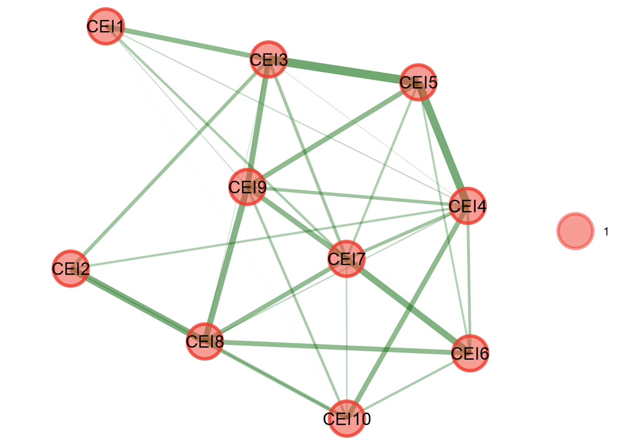

Figure 1. Community Estimation

```r
set.seed(123)
communities <- bootEGA(CEI_items,
                       model = "glasso",
                       type = "resampling",
                       iter = 500,
                       typicalStructure = TRUE,
                       plot.typicalStructure = TRUE)
```

### 3.1.2. Community Stability

Items were retained within their assigned communities only when their stability coefficients exceeded 0.70. Items falling below this threshold were excluded due to their potential to undermine the structural integrity of the corresponding dimension.

```r
# Structural consistency
communities.dimstab <- dimensionStability(communities)
```

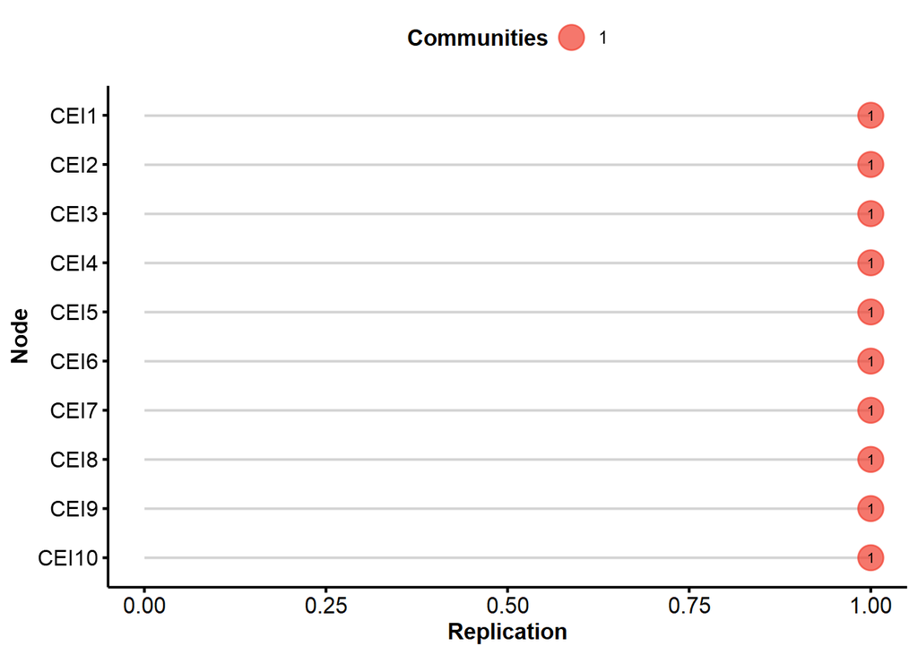

Figure 2. Community Stability

## 3.2. Gaussian Graphical Models (GGMs)

### 3.2.1. Network Estimation

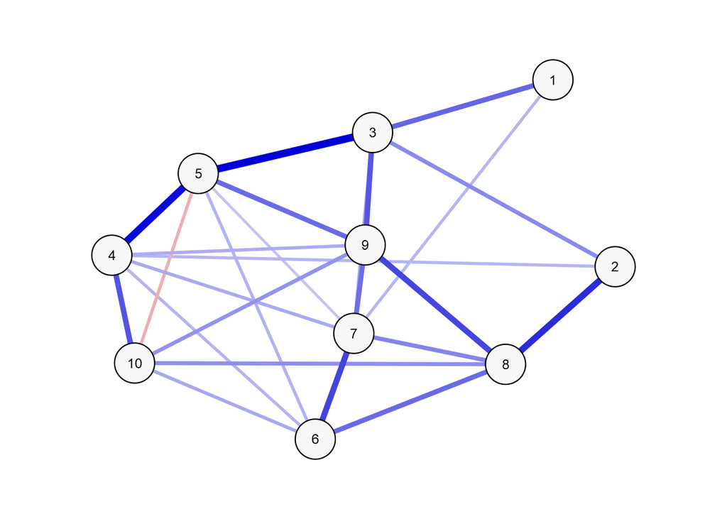

Figure 3. Gaussian Graphical Model Estimation

```r
group_list <- c(rep('Curiosity and Exploration Inventory-II',10))

CEI_poly <- polychoric(CEI_items)

CEI_glasso <- qgraph::qgraph(CEI_poly$rho, layout = "spring", graph = "glasso",color = 'grey97',
                            sampleSize = nrow(CEI_items), labels = c(1:length(CEI_items)), groups =
                              group_list, theme = "colorblind", nodeNames = names(CEI_items),
                            threshold = TRUE, legend = FALSE, border.width=1, asize=7, unCol="black",
                            vsize=6, esize=6,border.color="black",legend.cex=1.5, layoutScale=c(0.9,0.9))
```

```r
possible_edges <- (ncol(CEI_items)*(ncol(CEI_items)-1))/2
real_edges <- length(CEI_glasso$Edgelist$weight)
density <- round(real_edges/possible_edges*100, digits = 2)
```

### 3.2.2. Network characterization

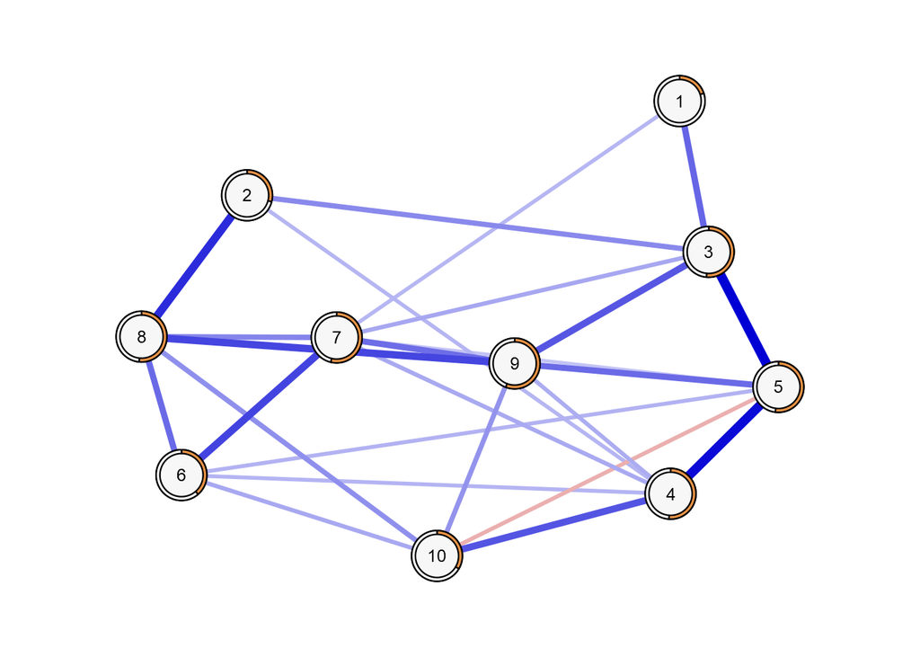

Figure 4. Gaussian Graphical Model Characterization

```r
CEI_matrix <- as.matrix(CEI_items)
invisible(capture.output({SV_mgm <-mgm(
    data = CEI_matrix,
    type = rep("g", length(CEI_items)),
    level = rep(1, length(CEI_items)),
    k = 2,
    verbatim = TRUE,
    warnings = TRUE
  )
}))

#Predice la varianza explicada de cada nodo y otros parametros
SV_predic <- predict(SV_mgm, CEI_items, error.continuous = "VarExpl")

CEI_glasso_predicted <- qgraph::qgraph(
  cor_auto(CEI_items),
  layout = "spring",
  graph = "glasso",
  sampleSize = nrow(CEI_items),
  color = "grey97",
  labels = 1:length(CEI_items),
  groups = group_list,
  theme = "colorblind",
  nodeNames = names(CEI_items),
  threshold = TRUE,
  legend = FALSE,
  pie = SV_predic$errors$R2,
  pieColor = pieColor,
  border.width = 1,
  border.color = "black",
  asize = 7,
  unCol = "black",
  vsize = 6,
  esize = 6,
  legend.cex = 1.5,
  layoutScale = c(0.9, 0.9)
)
```

## 3.3. Centrality Measures

### 3.3.1. Centality Estimation

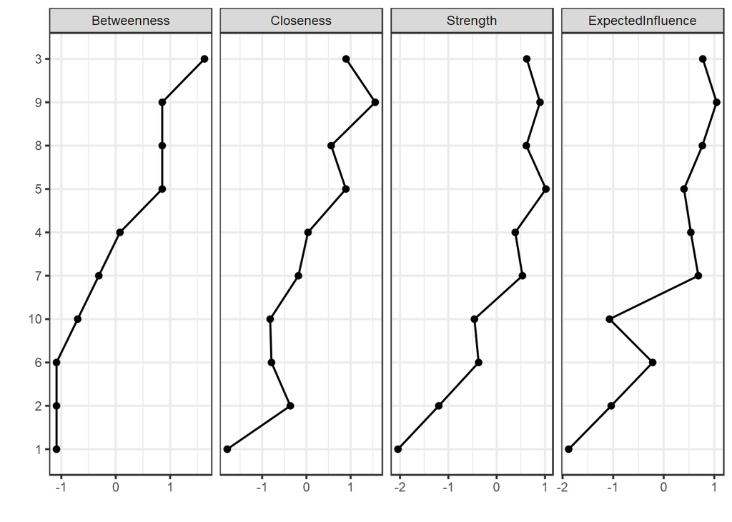

Figure 5. Centrality Measures Estimation

```r
centrality_CEI <- centralityPlot(CEI_glasso, include =
                                  c("Betweenness","Closeness","Strength","ExpectedInfluence"),
                                orderBy ="Betweenness", scale = "z-scores")
```

### 3.3.2. Centrality Stability

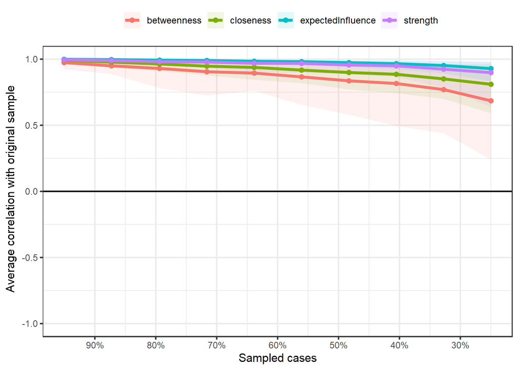

Figure 6. Centrality Measures Stability

```r
# 1. Estimar la red con EBICglasso
glasso_net <- estimateNetwork(CEI_items,
                              default = "EBICglasso",
                              corMethod = "cor_auto",
                              verbose = FALSE)

# 2. Bootstrap de estabilidad (case-dropping)
set.seed(123)
boot_results <- bootnet(glasso_net,
                        nBoots = 1000,
                        nCores = 8,
                        type = "case",
                        statistics = "all",
                        verbose = FALSE)

# 3. Plot de estabilidad de centralidad (bootstrap case-dropping)
plot(boot_results,
     statistics = c("strength", "closeness", "betweenness","expectedInfluence"),
     labels = TRUE,
     order = "sample",
     legend = TRUE,
     color = "darkblue",
     line = TRUE,
     main = "Bootstrap Centrality Stability (Case Dropping)")
```

```r
# 4. Coeficientes de estabilidad de centralidad
cs_coeffs <- corStability(boot_results, verbose = FALSE)

# Crear tabla
cs_table <- data.frame(
  Centrality = c("Betweenness", "Closeness", "Strength", "ExpectedInfluence"),
  CS_Coefficient = round(c(cs_coeffs[1], cs_coeffs[2], cs_coeffs[10], cs_coeffs[6]), 3)
)
row.names(cs_table) <- 1:4

# Mostrar como tabla en R Markdown
knitr::kable(cs_table, caption = "Table 10: Centrality Stability Coefficients (CS)")
```

Table 10: Centrality Stability Coefficients (CS)

| Centrality | CS_Coefficient |
| --- | --- |
| Betweenness | 0.439 |
| Closeness | 0.673 |
| Strength | 0.750 |
| ExpectedInfluence | 0.750 |

# 4. NETWORK COMPARISON

## 4.1. General

```r
CEI_male <- CEI_invariance[CEI_invariance$gender == "Male",-length(CEI_invariance)]
CEI_female <- CEI_invariance[CEI_invariance$gender == "Female",-length(CEI_invariance)]

set.seed(12)
EN_male = estimateNetwork(CEI_male, default = "EBICglasso", corMethod = "cor_auto")
EN_female = estimateNetwork(CEI_female, default = "EBICglasso", corMethod = "cor_auto")
```

```r
set.seed(123)
invisible(capture.output({
  res <- NCT(
    CEI_female,
    CEI_male,
    p.adjust.methods = "BH",
    binary.data = FALSE,
    test.edges = TRUE,
    edges = "all",
    it = 1000
  )
}))

female_str <- round(res$glstrinv.sep[1], 3)
male_str <- round(res$glstrinv.sep[2], 3)
p_str <- ifelse(res$glstrinv.pval < 0.001, "p < 0.001", paste0("p = ", round(res$glstrinv.pval, 3)))

dif_net <- round(res$nwinv.real, 3)
p_net <- ifelse(res$nwinv.pval < 0.001, "p < 0.001", paste0("p = ", round(res$nwinv.pval, 3)))

p_edges <- paste(
  dplyr::filter(res$einv.pvals, `p-value` < 0.05) %>%
    dplyr::mutate(pair = paste(Var1, "-", Var2)) %>%
    dplyr::pull(pair),
  collapse = ", "
)
```

In terms of global strength, the female network showed a lower overall connectivity (S = 4.157) compared to the male network (S = 4.57). This difference was statistically significant (p = 0.045), suggesting that the male network is more strongly connected overall.

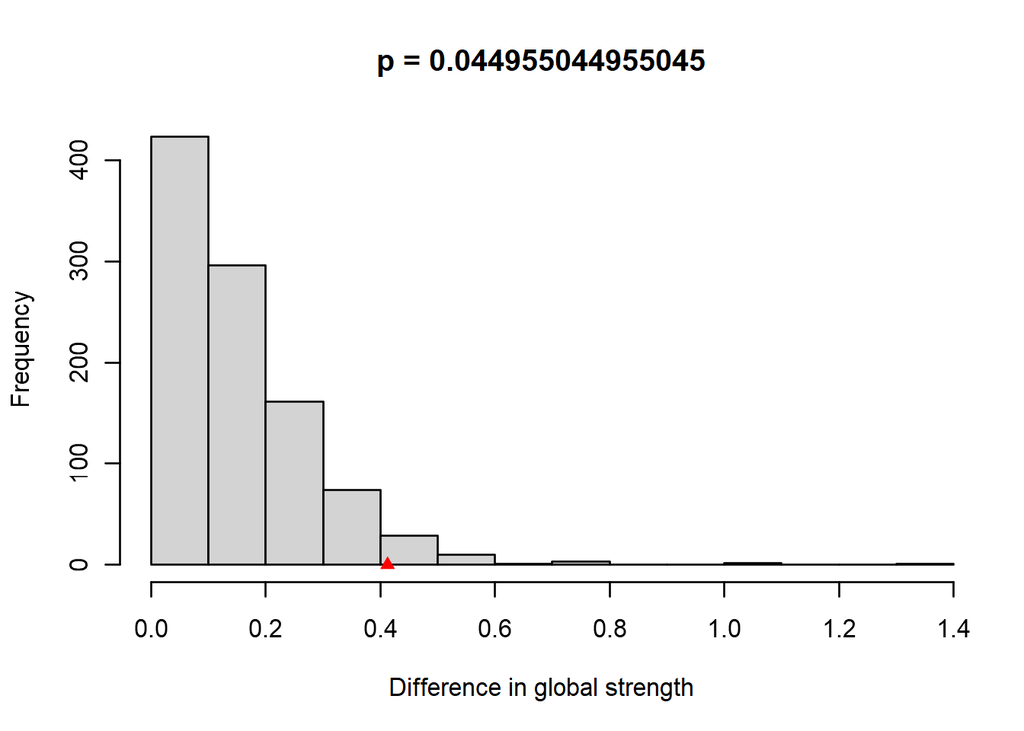

Figure 7. P-values for differences in network strength between genders

```r
plot(res, what="strength")
```

The network structure invariance test revealed a difference of 0.203 between the female and male networks. This difference was **not statistically significant** (p = 0.21), suggesting that the overall structure of the two networks can be considered similar.

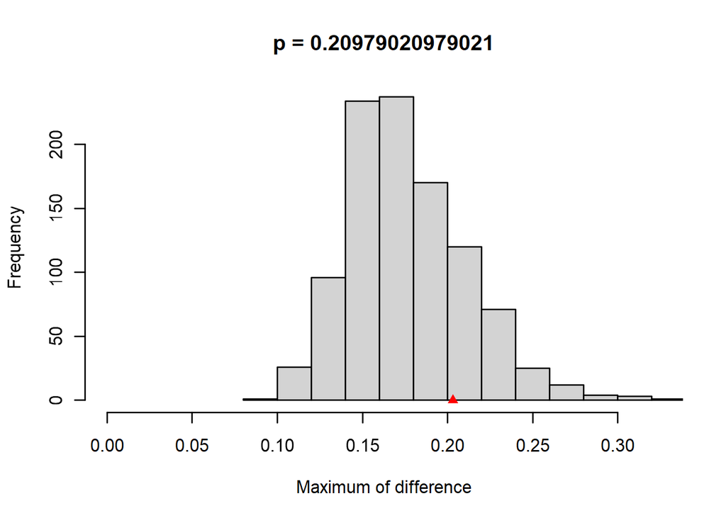

Figure 8. P-values for differences in network structure between genders

```r
plot(res, what="network")
```

The Network Comparison Test did not identify any statistically significant differences in edge strength between the female and male networks after applying the Benjamini-Hochberg procedure to correct p-values for multiple comparisons. The significance level was set at the conventional threshold of 0.05.

## 4.2. Networks by Gender

**Female’s Network**

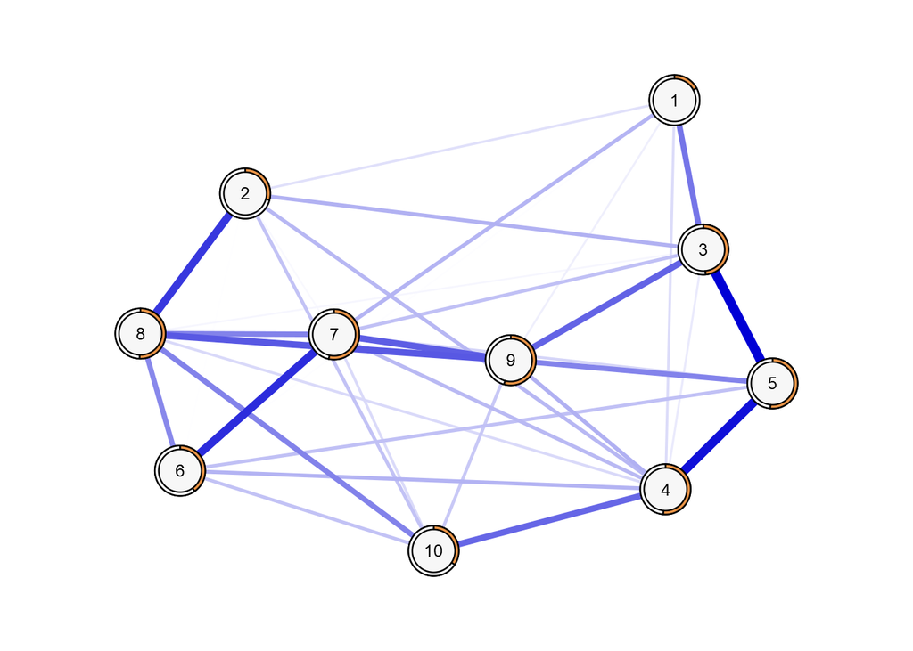

Figure 9. Networks of Female Participants

```r
# --- FEMALE GROUP ---

# Convert data to matrix
CEI_female_matrix <- as.matrix(CEI_female)

# Estimate MGM model (defines number of variables, order of interactions, and input data)
invisible(capture.output({
  CEI_mgm_female <- mgm(
    data = CEI_female_matrix,
  type = rep("g", length(CEI_female)),
  level = rep(1, length(CEI_female)),
  k = 2,
  warnings = TRUE,
  verbatim = TRUE
  )
}))

# Predict explained variance (R²) and other node-level metrics
CEI_predic_female <- predict(
  CEI_mgm_female,
  CEI_female,
  error.continuous = "VarExpl"
)

# Plot the network with R² represented as pie charts on nodes
CEI_glasso_predicted_female <- plot(
  EN_female,  # network object for the female group
  layout = CEI_glasso_predicted$layout,
  color = "grey97",
  sampleSize = nrow(CEI_female),
  labels = 1:length(CEI_female),
  groups = group_list,
  theme = "colorblind",
  nodeNames = names(CEI_items),
  threshold = FALSE,
  legend = FALSE,
  pie = CEI_predic_female$errors$R2,
  pieColor = pieColor,
  border.width = 1,
  asize = 7,
  unCol = "black",
  vsize = 6,
  esize = 6,
  border.color = "black",
  legend.cex = 1.5,
  layoutScale = c(0.9, 0.9)
)
```

**Male’s network**

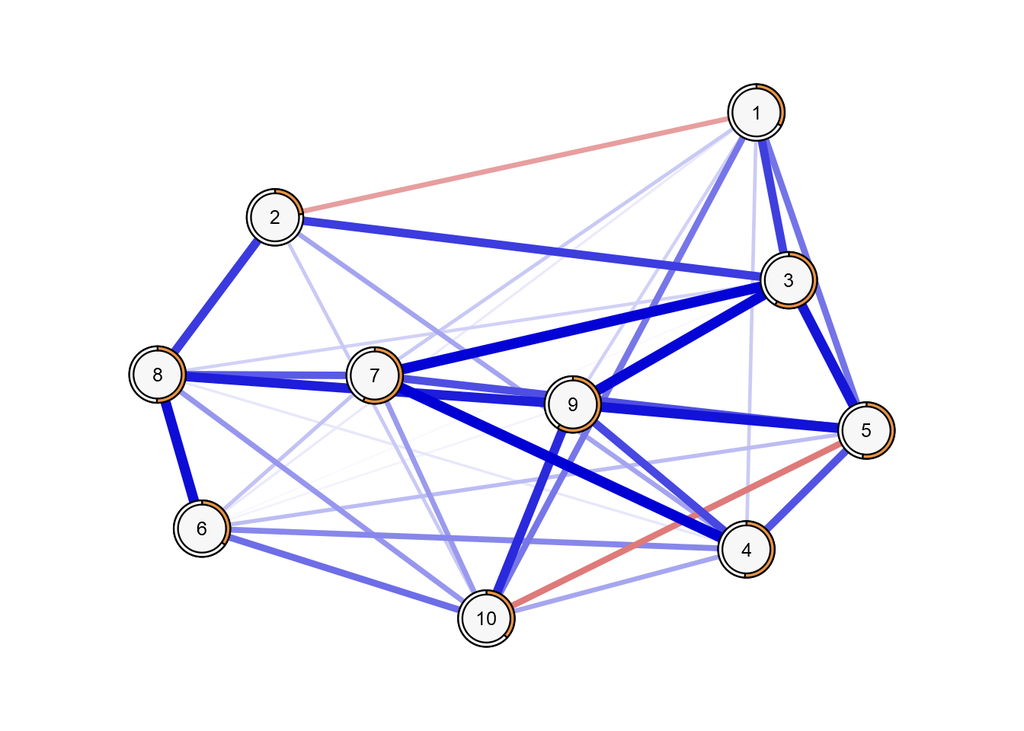

Figure 10. Networks of Male Participants

```r
# --- MALE GROUP ---

# Convert data to matrix
CEI_male_matrix <- as.matrix(CEI_male)

# Estimate MGM model (defines number of variables, order of interactions, and input data)
invisible(capture.output({
  CEI_mgm_male <- mgm(
    data = CEI_male_matrix,
    type = rep("g", length(CEI_male)),
    level = rep(1, length(CEI_male)),
    k = 2,
    warnings = TRUE,
    verbatim = TRUE
  )
}))

# Predict explained variance (R²) and other node-level metrics
CEI_predic_male <- predict(
  CEI_mgm_male,
  CEI_male,
  error.continuous = "VarExpl"
)

# Plot the network with R² represented as pie charts on nodes
CEI_glasso_predicted_male <- plot(
  EN_male,  # network object for the male group
  layout = CEI_glasso_predicted$layout,
  color = "grey97",
  sampleSize = nrow(CEI_male),
  labels = 1:length(CEI_male),
  groups = group_list,
  theme = "colorblind",
  nodeNames = names(CEI_items),
  threshold = FALSE,
  legend = FALSE,
  pie = CEI_predic_male$errors$R2,
  pieColor = pieColor,
  border.width = 1,
  asize = 7,
  unCol = "black",
  vsize = 6,
  esize = 6,
  border.color = "black",
  legend.cex = 1.5,
  layoutScale = c(0.9, 0.9)
)
```

## 4.3. Centrality Measures

To evaluate the invariance of the centrality measures network across genders.

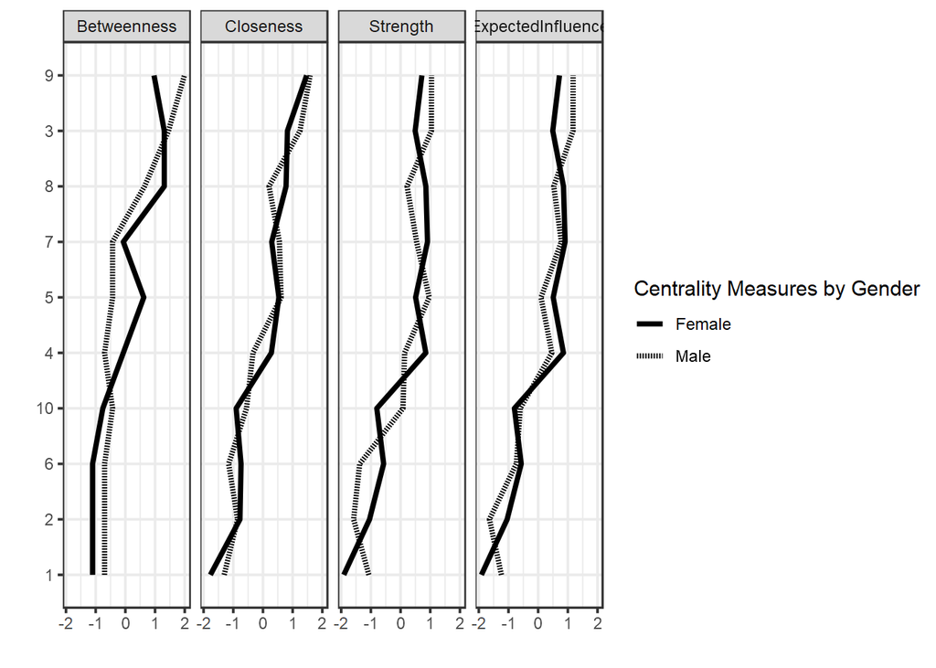

Figure 11. Centrality comparison between female and male networks

```r
# Compare centralities between networks
network_comparison <- compareCentrality(
  CEI_glasso_predicted_female,
  CEI_glasso_predicted_male,
  include = "all",
  legendName = "Centrality Measures by Gender",
  net1Name = "Female",
  net2Name = "Male"
)
plot(network_comparison)
```

```r
set.seed(12)
invisible(capture.output({
  nct_test_centrality <- NCT(
    EN_female,
    EN_male,
    it = 1000,
    test.centrality = TRUE,
    p.adjust.methods = "BH",
    centrality = c("closeness", "betweenness", "strength", "expectedInfluence"),
  )
}))
# Extract p-values and convert to data frame
centrality_pvals <- as.data.frame(nct_test_centrality$diffcen.pval)

# Round to 3 decimals (and adjust "< 0.001" if you want a more elegant output)
centrality_pvals_rounded <- round(centrality_pvals, 3)

# Optional: add row names as a column
centrality_pvals_rounded$Node <- rownames(centrality_pvals_rounded)
centrality_pvals_rounded <- centrality_pvals_rounded[, c("Node", setdiff(names(centrality_pvals_rounded), "Node"))]
row.names(centrality_pvals_rounded) <- 1:10

# Display as table
kable(centrality_pvals_rounded, caption = "Table 11. P-values for Centrality Differences (NCT Test)")
```

Table 11. P-values for Centrality Differences (NCT Test)

| Node | closeness | betweenness | strength | expectedInfluence |
| --- | --- | --- | --- | --- |
| CEI1 | 0.811 | 1.000 | 0.559 | 0.811 |
| CEI2 | 1.000 | 1.000 | 1.000 | 0.811 |
| CEI3 | 0.811 | 1.000 | 0.811 | 0.811 |
| CEI4 | 1.000 | 0.841 | 1.000 | 1.000 |
| CEI5 | 0.811 | 0.811 | 0.811 | 1.000 |
| CEI6 | 1.000 | 1.000 | 1.000 | 1.000 |
| CEI7 | 0.811 | 1.000 | 1.000 | 1.000 |
| CEI8 | 1.000 | 1.000 | 1.000 | 1.000 |
| CEI9 | 0.811 | 0.811 | 0.811 | 0.811 |
| CEI10 | 0.811 | 1.000 | 0.811 | 1.000 |

# 5. BAYESIAN NETWORK

The construction of the **Bayesian network (BN)** is carried out in two steps. Firstly, the estimation of the **directed acyclic graph (DAG)** is performed, and secondly, the **BN model** is fitted and validated with the study dataset.

## 5.1. DAG Estimation

For the **DAG** estimation phase, the *PC Stable* algorithm with no restrictions was employed. To ensure stability in the obtained **DAG**, a total of 200 bootstrap samples were drawn, and only the edges with a strength greater than 0.85 and a direction greater than 0.5 were retained in the final model.

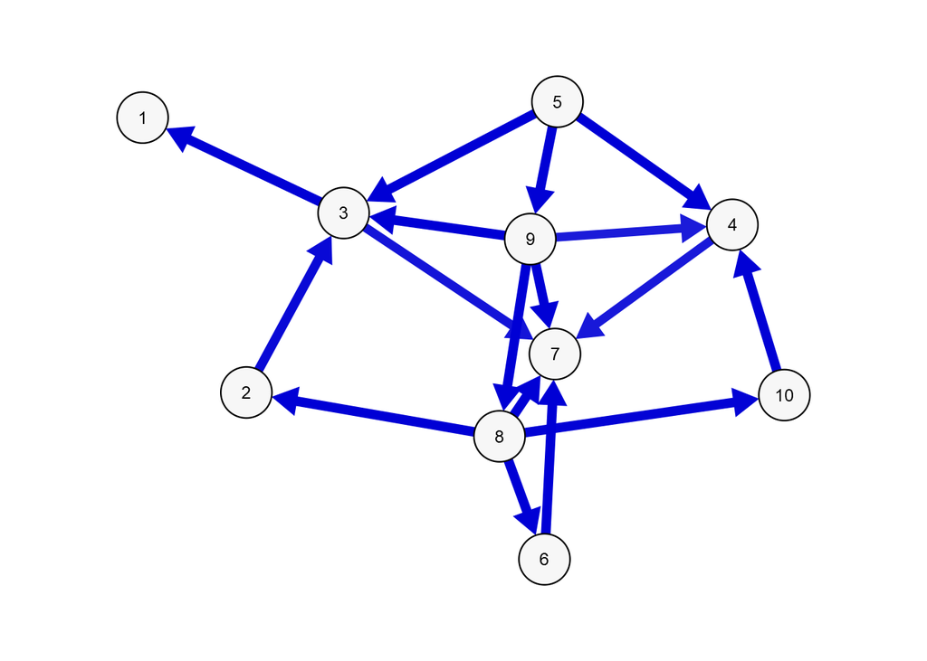

Figure 12. Directed Acyclic Graph (DAG)

```r
set.seed(1234)
bootstr <- boot.strength(CEI_items, R = 200, algorithm = "pc.stable")

avgnet <- averaged.network(bootstr, threshold = 0.85)

sp <- strength.plot(avgnet, bootstr, shape = "ellipse", render = FALSE)

group_list <- c(rep('Curiosity and Exploration Inventory-II',10))

CEI_DAG_qgraph <- qgraph::qgraph(sp, layout = "spring",
                                    sampleSize=nrow(CEI_items), nodeNames = names(CEI_items),
                                    border.width=1, asize=7, unCol="black", vsize=6, esize=6
                                    ,border.color="black",color = 'grey97',theme = "colorblind",
                                    groups = group_list,labels = c(1:length(CEI_items)),
                                    legend.cex=1.5,layoutScale=c(0.9,0.9), legend = FALSE)
```

## 5.2. Bayesian Network Validation

To fit and validate the **BN model** in the second phase of the process, the dataset was subdivided into 10 folds. A routine was implemented in which 90% of the folds were used to train the model, and the remaining 10% were used for testing. This cross-validation routine was repeated until all potential combinations were explore.

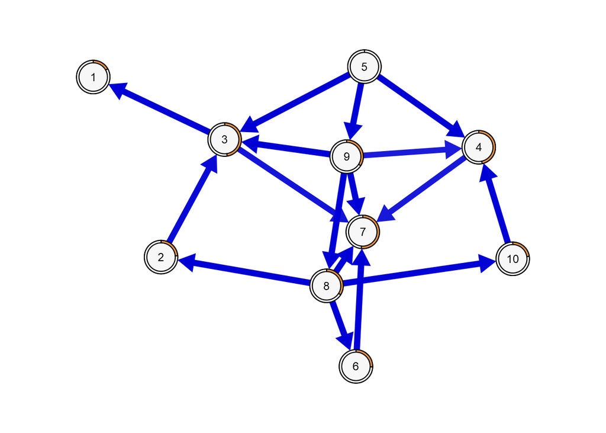

Figure 13. Bayesian Network (BN) Model

```r
pieColor <- c(rep("#EB9446", length(CEI_items))) # Da color al borde del nodo color naranja
#Cross-validation (Check spatial cross-validation: blockCV)
set.seed(1234)
# Split data in 5 sets
kf <- dismo::kfold(nrow(CEI_items), k = 10) # k-fold partitioning
models_fit <- c()

for (var in names(CEI_items)) {
  kfold_fit <- c()
  aux_base <- data.frame('variable'=var)
  if(is.numeric(CEI_items[[var]])){
    for(k in 1:10) {
      test <- CEI_items[kf == k, ]
      train <- CEI_items[kf != k, ]

      training <- bn.fit(avgnet,train)
      pred <- predict(training, node = var, data = test)

      z <- data.frame( R2 = R2(pred, test[[var]]),
                       RMSE = RMSE(pred, test[[var]]),
                       MAE = MAE(pred, test[[var]]))
      if(is.na(z$R2)){
        z[is.na(z$R2),] <- 0
      }
      kfold_fit <- rbind(kfold_fit, z)
    }

    z <- apply(kfold_fit, 2, mean)
    z <- cbind(aux_base,as.data.frame(t(z)))
    models_fit <- rbind(models_fit, z)
  }else{
    for(k in 1:10) {
      # Split data in test and train
      test <- CEI_items[kf == k, ]
      train <- CEI_items[kf != k, ]

      training <- bn.fit(avgnet,train)
      pred <- predict(training, node = var, data = test)

      validation <- confusionMatrix(as.factor(pred),test[[var]])
      z1 <- as.data.frame(t(validation$overall))

      if(length(levels(CEI_items[[var]])) > 2){
        z2 <- as.data.frame(t(sapply(as.data.frame(validation$byClass),mean)))
      }else{
        z2 <- as.data.frame(t(sapply(validation$byClass,mean)))
      }
      z <- cbind(z1, z2)

      kfold_fit <- rbind(kfold_fit, z)
    }
    z <- apply(kfold_fit, 2, mean)
    z <- cbind(aux_base,z)
    models_fit <- rbind(models_fit, z)
  }
}

CEI_BN_qgraph <- qgraph::qgraph(sp, layout = "spring",pie = models_fit$R2,pieColor = pieColor,
                               sampleSize=nrow(CEI_items), nodeNames = names(CEI_items),
                               border.width=1, asize=7, unCol="black", vsize=6, esize=6
                               ,border.color="black",color = 'grey97',theme = "colorblind",
                               groups = group_list,labels = c(1:length(CEI_items)),
                               legend.cex=1.5,layoutScale=c(0.9,0.9), legend = FALSE)
```

# 6. PREDICTAIBILITY CAPACITY

A notable gender difference was also observed in **Item 1**, with a discrepancy of 0.16 in R² between females and males, indicating lower predictability for the female group on this item.

```r
# Item labels
items <- paste("Item", 1:10)

# GGM - General
ggm_general <- SV_predic$errors %>%
  transmute(
    Variable = items,
    R2_gen = round(R2, 3),
    RMSE_gen = round(RMSE, 3)
  )

# GGM - Female
ggm_female <- CEI_predic_female$errors %>%
  transmute(
    R2_fem = round(R2, 3),
    RMSE_fem = round(RMSE, 3)
  )

# GGM - Male
ggm_male <- CEI_predic_male$errors %>%
  transmute(
    R2_male = round(R2, 3),
    RMSE_male = round(RMSE, 3)
  )

# BN model
bn <- models_fit %>%
  transmute(
    R2_bn = ifelse(R2 == 0, "-", round(R2, 3)),
    RMSE_bn = ifelse(RMSE == 0, "-", round(RMSE, 3))
  )

# Combine all safely
final_table <- bind_cols(ggm_general, ggm_female, ggm_male, bn)

# Set final column names to just "R²" and "RMSE" per section
names(final_table) <- c(
  "Variable",
  rep(c("R²", "RMSE"), times = 4)  # General, Female, Male, BN
)

# Render with multi-level header
final_table %>%
  kable(align = "lcccccccc", booktabs = TRUE,
        caption = "Table 12. Explained variance and RMSE of partial-correlation network (GGM) and BN models") %>%
  add_header_above(c(" " = 1,
                     "General" = 2,
                     "Female" = 2,
                     "Male" = 2,
                     " " = 2)) %>%
    add_header_above(c(" " = 1,
                     "GGMs" = 6,
                     "BN" = 2)) %>%
  kable_styling(full_width = FALSE, position = "center")
```

Table 12. Explained variance and RMSE of partial-correlation network (GGM) and BN models

GGMs

BN

General

Female

Male

Variable

R²

RMSE

R²

RMSE

R²

RMSE

R²

RMSE

Item 1

0.201

0.893

0.171

0.910

0.329

0.817

0.169

0.826

Item 2

0.291

0.842

0.292

0.841

0.231

0.875

0.237

0.993

Item 3

0.515

0.696

0.486

0.716

0.581

0.646

0.477

0.731

Item 4

0.511

0.699

0.515

0.696

0.509

0.699

0.467

0.703

Item 5

0.520

0.692

0.515

0.696

0.523

0.689

Item 6

0.387

0.783

0.402

0.773

0.348

0.805

0.256

0.975

Item 7

0.538

0.680

0.535

0.682

0.568

0.656

0.515

0.749

Item 8

0.516

0.695

0.506

0.702

0.504

0.703

0.34

0.872

Item 9

0.558

0.664

0.544

0.675

0.592

0.637

0.341

0.823

Item 10

0.335

0.815

0.343

0.810

0.369

0.793

0.227

1.101